# Geometrisches Gesetz der Großen Zahlen

nach einem Vortrag von Jan Kallsen

# Das Gesetz der Großen Zahlen…

Der Mittelwert identischer, unabhängiger Zufallsvariablen konvergiert gegen ihren Erwartungswert:

$$\frac{\sum_{k=1}^n X_k}{n} \rightarrow E\left[X_k\right]$$

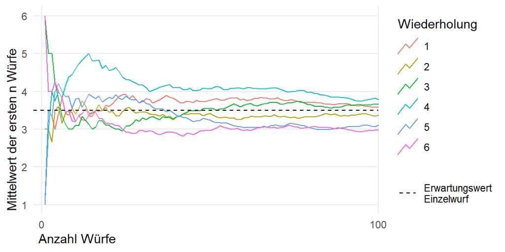

# … gilt auch für das geometrische Mittel …

$$\sqrt[n]{\prod_{k=1}^n X_k} \rightarrow\ ??$$

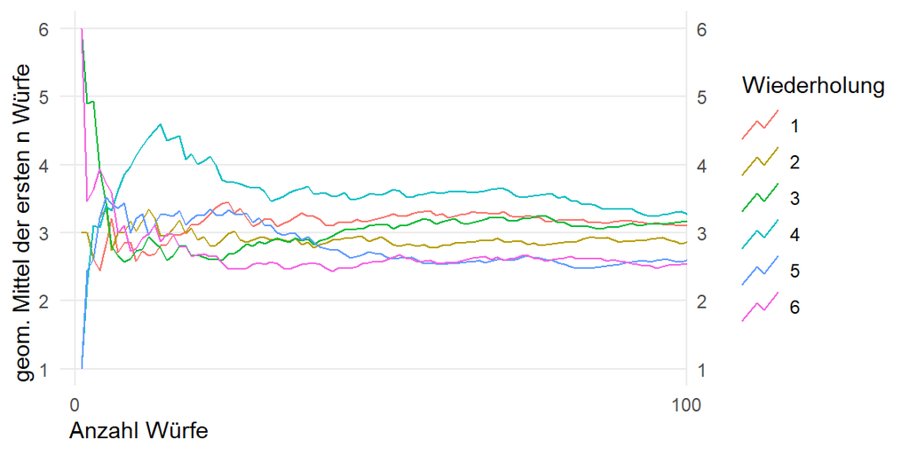

# … allerdings mit anderem Grenzwert.

Der Grenzwert lässt sich mit dem “normalen” Gesetz der Großen Zahlen herleiten:

$$\begin{align*}
\sqrt[n]{\prod_{k=1}^n X_k} &= \exp\left(\frac{\sum_{k=1}^{n}\log X_k}{n}\right)\\
&\rightarrow \exp\Big(E[\log X]\Big) \\
&\approx 1 + E[X] - \frac{Var[X]}{2}
\end{align*}$$

Für das Würfelbeispiel erhält man $\approx 3$, was gut zur Simulation oben passt.

# Arithmetisches und Geometrisches Mittel im Vergleich

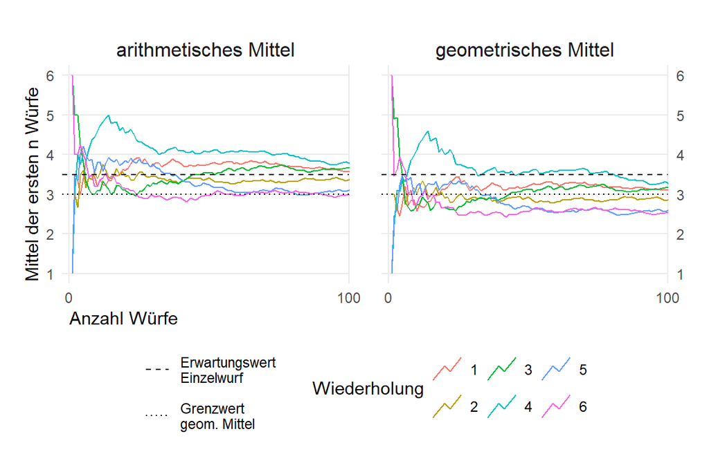

# Und was machen wir jetzt damit?

Wir schauen uns mal eine fiktive Finanzanlage mit jährlich unabhängiger, normalverteilter Rendite an.

- Welche mittlere Rendite (geom. Mittel) kann ich (langfristig) erwarten von einem Asset mit Performanceerwartung +10% und Vola 20%?

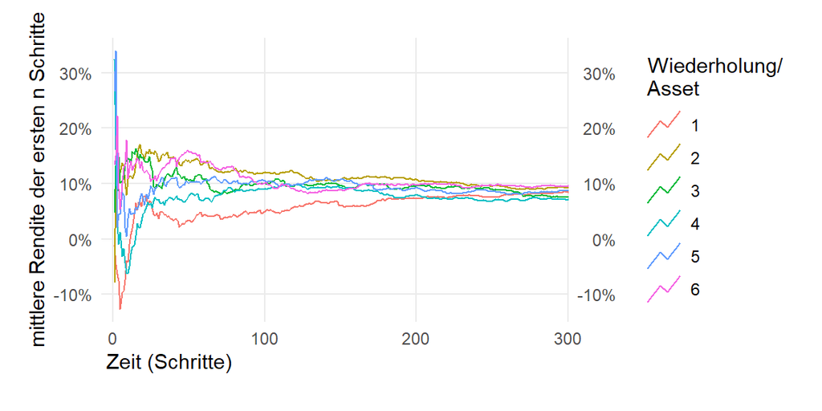

Das langfristige Mittel bleibt sichtbar unter dem Erwartungswert für jede einzelne Periode von +10%. Mit der Formel von oben ergibt sich:

$$\begin{align*}
\sqrt[n]{\prod_{k=1}^n (1+X_k)}\ \rightarrow \ \approx \ & 1 + E[X] - \frac{Var[X]}{2} \\
& 1 +\ 10\%\ -\ \ 4\%/2\ \ \ =\ \ 1 + 8\%
\end{align*}$$

Die Mittlere Rendite liegt somit bei ca. +8% pro Zeitschritt.

Wenn nun bei gleicher Vola die Rendite niedriger ist, kann der Grenzwert auch negativ werden. Hier zum Beispiel mit Erwartungswert 1% für die Performance im Einzelschritt. Die langfristige Entwicklung ist dann negativ. Betrachtet man die Entwicklung eines vorgegebenen Anfangsvermögen, so sinkt dieses exponentiell.

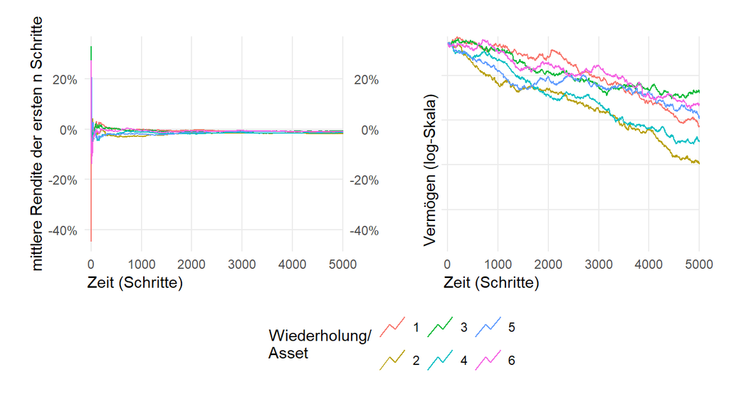

Nun kombinieren wir mehreren solchen Anlagen zu einem Portfolio, d.h. wir kaufen zu Beginn gleiche Anteile von allen verfügbaren Anlagen. Diese können wir dann entweder einfach halten (‘plain portfolio’) oder wir gleichen nach jedem Zeitschritt die Anteile wieder an so dass der Anteil der einzelnen Anlagen am Portfolio immer gleich ist (‘balanced portfolio’).

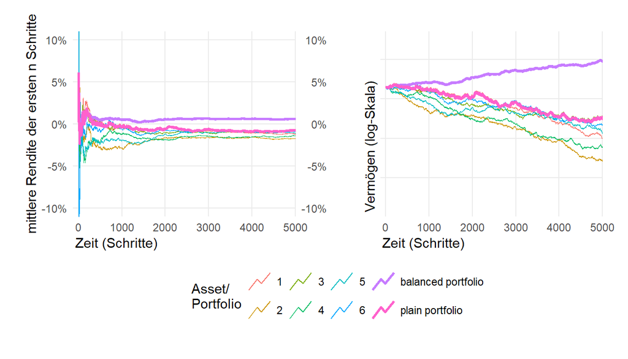

Wenn wir also nach jedem Schritt etwas von denjenigen Anlagen verkaufen, die ‘gut gelaufen’ sind und dafür von denen die ‘schlecht gelaufen’ sind nachkaufen, können wir die Rendite des Portfolios deutlich erhöhen!